# Distributions

James M. Flegal

## Agenda

- Random number generation
- Distributions in R
- Distributional Models
- Moments, generalized moments, likelihood
- Visual comparisons and basic testing

## Random number generation

How does R get “random” numbers?

- It doesn’t, instead it uses pseudorandom numbers that we hope are indistinguishable from random numbers
- Pseudorandom generators produce a deterministic sequence that is indistinguishable from a true random sequence if you don’t know how it started
- Why? Truly random numbers are expensive

## Random number generation

- Pseudorandom generators produce a sequence of Uniform$(0,1)$ random variates
- [Linear congruential generator](https://en.wikipedia.org/wiki/Linear_congruential_generator) is one of the oldest and best-known pseudorandom number generator algorithms
- Other distributions usually based such a sequence
- Example: If $U \sim \text{Unif}(0,1)$ then $-\beta \ln (1-U) \sim \text{Exp}(\beta)$
- More on this later …

## Example: `runif()`

```r
runif(1:10)
```

```
##  [1] 0.9473717 0.7757503 0.7620696 0.6479452 0.6269060 0.4509551 0.9870357
##  [8] 0.1537041 0.2177579 0.9817671
```

```r
set.seed(10)
runif(1:10)
```

```
##  [1] 0.50747820 0.30676851 0.42690767 0.69310208 0.08513597 0.22543662
##  [7] 0.27453052 0.27230507 0.61582931 0.42967153
```

```r
set.seed(10)
runif(1:10)
```

```
##  [1] 0.50747820 0.30676851 0.42690767 0.69310208 0.08513597 0.22543662
##  [7] 0.27453052 0.27230507 0.61582931 0.42967153
```

## Linear congruential generator

- Easily implemented and fast
- Modulo arithmetic via storage-bit truncation
- Defined as
  $$X_{n+1}=\left(aX_{n}+c\right)~~{\bmod {~}}~m$$
  where $X$ is the sequence of pseudorandom values

## Linear congruential generator

```r
seed <- 10
new.random <- function (a=5, c=12, m=16) {
out <- (a*seed + c) %% m
seed <<- out
return(out)
}
out.length <- 20
variates <- rep (NA, out.length)
for (kk in 1:out.length) variates[kk] <- new.random()
variates
```

```
##  [1] 14  2  6 10 14  2  6 10 14  2  6 10 14  2  6 10 14  2  6 10
```

## Linear congruential generator

```r
variates <- rep (NA, out.length)
for (kk in 1:out.length) variates[kk] <- new.random(a=131, c=7, m=16)
variates
```

```
##  [1]  5  6  9  2 13 14  1 10  5  6  9  2 13 14  1 10  5  6  9  2
```

```r
variates <- rep (NA, out.length)
for (kk in 1:out.length) variates[kk] <- new.random(a=129, c=7, m=16)
variates
```

```
##  [1]  9  0  7 14  5 12  3 10  1  8 15  6 13  4 11  2  9  0  7 14
```

## Linear congruential generator

```r
variates <- rep (NA, out.length)
for (kk in 1:out.length) variates[kk] <- new.random(a=1664545, c=1013904223, m=2^32)
variates
```

```
##  [1] 1037207853 2090831916 4106096907  768378826 3835752553 1329121000
##  [7] 2125006663 2668506502 3581687205 2079234980 2067291011 2197025090
## [13] 3748878561 2913996384  758844863 4029469438 2836748829 1458315036
## [19] 2399149563 2766656186
```

## How to distinguish non-randomness?

- Look at period
- Missing some values
- Proper distribution in the limit
- Autocorrelation
- Gets harder for higher dimensions

## Distributions

- Beta, Binomial, Cauchy, Chi-Square, Exponential, F, Gamma, Geometric, Hypergeometric, Logistic, Log Normal, Negative Binomial, Normal, Poisson, Student t, Studentized Range, Uniform, Weibull, Wilcoxon Rank Sum Statistic, Wilcoxon Signed Rank Statistic
- Parameters of these distributions may not agree with textbooks
- Lots of distributions, but they all work the same way

## Distributions

Every distribution that R handles has four functions. There is a root name, for example, the root name for the normal distribution is `norm`. This root is prefixed by one of the letters

- `p` for "probability", the cumulative distribution function (c. d. f.)
- `q` for "quantile", the inverse c. d. f.
- `d` for "density", the density function (p. f. or p. d. f.)
- `r` for "random", a random variable having the specified distribution

## Distributions

- Beta, Binomial, Cauchy, Chi-Square, Exponential, F, Gamma, Geometric, Hypergeometric, Logistic, Log Normal, Negative Binomial, Normal, Poisson, Student t, Studentized Range, Uniform, Weibull, Wilcoxon Rank Sum Statistic, Wilcoxon Signed Rank Statistic
- `beta`, `binom`, `cauchy`, `chisq`, `exp`, `f`, `gamma`, `geom`, `hyper`, `logis`, `lnorm`, `nbinom`, `norm`, `pois`, `t`, `tukey`, `unif`, `weibull`, `wilcox`, `signrank`
- Exponential distribution has `pexp`, `qexp`, `dexp`, and `rexp`

## Exponential distribution

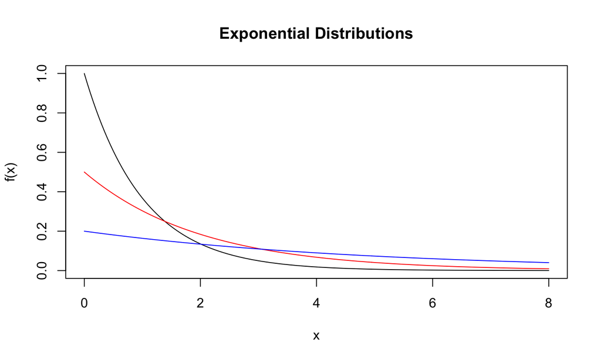

```r
this.range <- seq(0, 8, .05)
plot (this.range, dexp(this.range), ty="l", main="Exponential Distributions",
      xlab="x", ylab="f(x)")
lines (this.range, dexp(this.range, rate=0.5), col="red")
lines (this.range, dexp(this.range, rate=0.2), col="blue")
```

## Exponential distribution

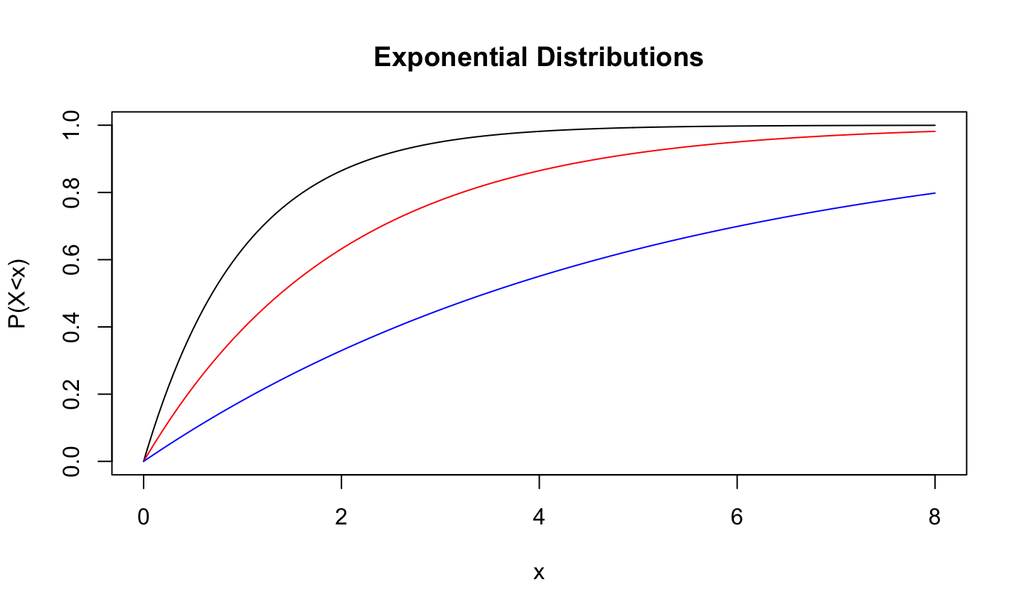

```r
this.range <- seq(0, 8, .05)
plot (this.range, pexp(this.range), ty="l", main="Exponential Distributions",
      xlab="x", ylab="P(X<x)")
lines (this.range, pexp(this.range, rate=0.5), col="red")
lines (this.range, pexp(this.range, rate=0.2), col="blue")
```

## Fitting distributional models

- Method of moments
- Match other summary statistics
- Maximize likelihood estimation

## Method of moments: Closed form

- Pick enough moments to identify the parameters, i.e. at least 1 moment per parameter
- Write moment equations in terms of the parameters, e.g. the gamma distribution
  $$\mu = as \text{ and } \sigma^2 = as^2$$
- Solve the system of equations (by hand)
  $$a = \mu^2 / \sigma^2 \text{ and } s=\sigma^2 / \mu$$
- Write a function

```r
gamma.est_MM <- function(x) {
m <- mean(x); v <- var(x)
return(c(shape=m^2/v, scale=v/m))
}
```

## Method of moments: Numerically

- Write functions to get moments from parameters (usually algebra)
- Set up the difference between data and model as another function

```r
gamma.mean <- function(shape,scale) { return(shape*scale) }
gamma.var <- function(shape,scale) { return(shape*scale^2) }
gamma.discrepancy <- function(shape,scale,x) {
  return((mean(x)-gamma.mean(shape,scale))^2 + (var(x)-gamma.mean(shape,scale))^2)
}
```

- Minimize your function

## Applies more generally

- Can match other data summaries, e.g. the median or ratios of quantiles
- If you can’t solve exactly, set up a discrepancy function and minimize it

## Maximum Likeihood

- Usually think of parameters as fixed and consider the probability of different outcomes, $f(x | \theta )$ with $\theta$ constant and $x$ changing
- Likelihood of a parameter value, i.e. $L(\theta)$ treats this a function of $\theta$
- Search over values of $\theta$ for the one that makes the data most likely
- Results in maximum likelihood estimate (MLE)

## Maximum Likeihood

- Suppose $x_1, \dots, x_n$ are i.i.d., then
  $$L(\theta) = \prod_{i=1}^{n} f(x_i | \theta )$$
- Tends to be computationally unstable since it may contain lots of small numbers
- Instead consider the log likelihood
  $$l(\theta) = \sum_{i=1}^{n} \log f(x_i | \theta )$$
- In pseudo-code

```r
loglike.foo <- function(params, x) {
  sum(dfoo(x=x,params,log=TRUE))
}
```

## What to do with the likelihood?

- Maximize it!
- Sometimes we can do the maximization by hand via calculus
- Gaussian, Poisson, Pareto, …
- More generally we'll consider numerical optimization
- Include a minus sign when using a minimization function

## Why use an MLE?

- Usually consistent: converges on the truth as we get more data
- Usually efficient: converges on the truth at least as fast as anything else
- Some settings where the maximum isn’t well-defined (e.g. $x_{min}$ for a Pareto)
- Sometimes data is too aggregated or mangled to use an MLE

## MLEs for univariate distributions

- `fitdistr` in `MASS` package
- Knows most standard distributions, but can also handle arbitrary probability density functions
- Starting value for the optimization is optional for some distributions, required for others (including user-defined densities)
- Returns parameter estimates and standard errors from large-$n$ approximations (so use cautiously)

## Example: Cat heart weights

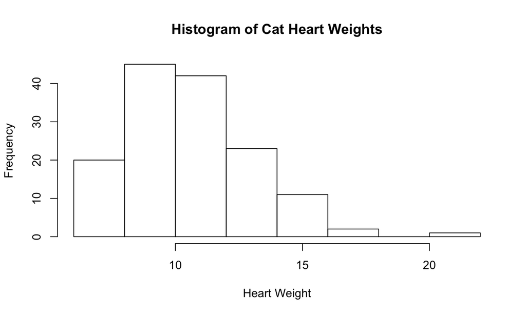

```r
library(MASS)
data("cats",package="MASS")
hist(cats$Hwt, xlab="Heart Weight", main="Histogram of Cat Heart Weights")
```

## Example: Cat heart weights

```r
fitdistr(cats$Hwt, densfun="gamma")
```

```
##      shape         rate
##   20.2998092    1.9095724
##  ( 2.3729250) ( 0.2259942)
```

## Checking the fit

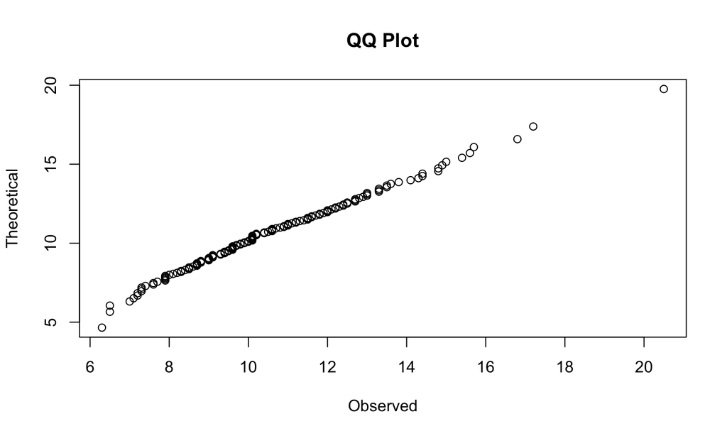

```r
cats.gamma <- gamma.est_MM(cats$Hwt)
qqplot(cats$Hwt, qgamma(ppoints(500), shape=cats.gamma["shape"],
      scale=cats.gamma["scale"]), xlab="Observed", ylab="Theoretical",
      main="QQ Plot")
```

## Checking the fit

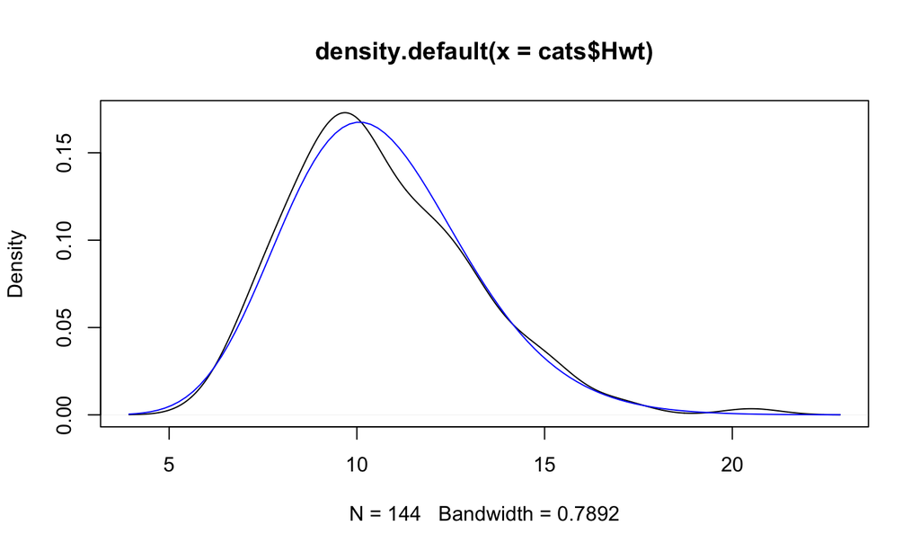

```r
plot(density(cats$Hwt)) # more on this later
curve(dgamma(x,shape=cats.gamma["shape"],scale=cats.gamma["scale"]),add=TRUE,col="blue")
```

## Calibration plots

- If the distribution is right, 50% of the data should be below the median, 90% should be below the 90th percentile, etc.
- Special case of calibration of probabilities: events with probability p% should happen about p% of the time, not more and not less
- Can look at calibration by calculating the (empirical) CDF of the (theoretical) CDF and plotting
- Ideal calibration plot is a straight line up the diagonal
- Systematic deviations are a warning sign

## Calibration plots

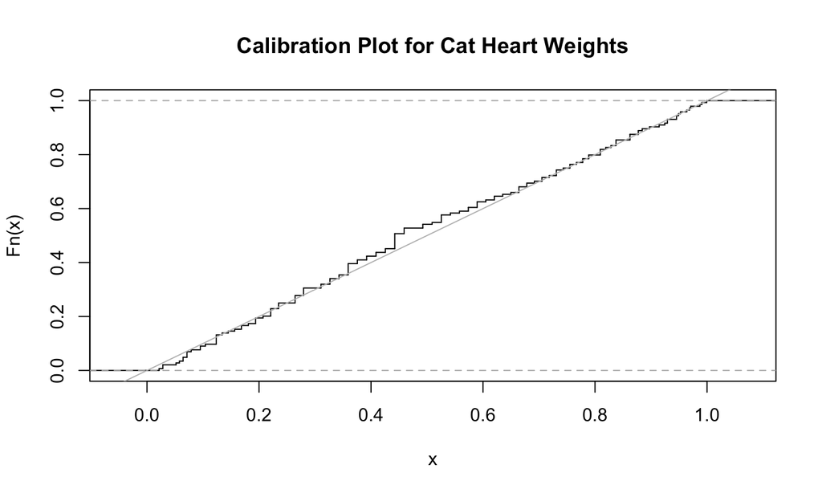

```r
plot(ecdf(pgamma(cats$Hwt, shape=cats.gamma["shape"], scale=cats.gamma["scale"])),
     main="Calibration Plot for Cat Heart Weights", verticals = T, pch = "")
abline(0,1,col="grey")
```

## Calibration plots

Exercise: Write a general function making a calibration plot that inputs a data vector, cumulative probability function, and parameter vector

## Kolmogorov-Smirnov test

- How much "error" is acceptable in a QQ plot or calibration plot?
- Alternatively, consider the biggest gap between theoretical and empirical CDF:
  $$D_{KS} = \max_{x} \left| F(x) - \hat{F}(x) \right|$$
- Useful because $D_{KS}$ has the same distribution if the theoretical CDF is fixed and correct
- Also works for comparing the empirical CDFs of two samples, to see if they came from the same distribution

## Kolmogorov-Smirnov test

```r
ks.test(cats$Hwt, pgamma, shape=cats.gamma["shape"], scale=cats.gamma["scale"])
```

```
##
##  One-sample Kolmogorov-Smirnov test
##
## data:  cats$Hwt
## D = 0.068637, p-value = 0.5062
## alternative hypothesis: two-sided
```

- Caution: Solution is more complicated (and not properly handled by built-in R) if parameters are estimated – Estimating parameters makes the fit look better than it really is
- Could estimate using (say) 80% of the data, and then check the fit on the remaining 20%

## Kolmogorov-Smirnov test

- Can also test whether two samples come from same distribution

```r
x <- rnorm(100, mean=0, sd=1)
y <- rnorm(100, mean=.5, sd=1)
ks.test(x, y)
```

```
##
##  Two-sample Kolmogorov-Smirnov test
##
## data:  x and y
## D = 0.28, p-value = 0.0007873
## alternative hypothesis: two-sided
```

## Chi-squared test

- Compare an actual table of counts to a hypothesized probability distribution

```r
M <- as.table(rbind(c(762, 327, 468), c(484, 239, 477)))
dimnames(M) <- list(gender = c("F", "M"), party = c("Democrat","Independent", "Republican"))
M
```

```
##       party
## gender Democrat Independent Republican
##      F      762         327        468
##      M      484         239        477
```

```r
Xsq <- chisq.test(M)
Xsq
```

```
##
##  Pearson's Chi-squared test
##
## data:  M
## X-squared = 30.07, df = 2, p-value = 2.954e-07
```

## Chi-squared test

- The p-value calculated by `chisq.test()` assumes that all the probabilities in `p` were fixed, not estimated from the data used for testing, so df = number of cells in the table −1
- If we estimate `q` parameters, we need to subtract `q` degrees of freedom

## Chi-squared test for continuous distributions

- Divide the range into bins and count the number of observations in each bin; this will be `x` in `chisq.test()`
- Use the CDF function `p` `foo` to calculate the theoretical probability of each bin; this is `p`
- Plug in to `chisq.test`
- If parameters are estimated, adjust

## Chi-squared test for continuous distributions

`hist()` gives us break points and counts:

```r
cats.hist <- hist(cats$Hwt,plot=FALSE)
cats.hist$breaks
```

```
## [1]  6  8 10 12 14 16 18 20 22
```

```r
cats.hist$counts
```

```
## [1] 20 45 42 23 11  2  0  1
```

Use these for a $\chi^2$ test

## Chi-squared test for continuous distributions

```r
# Why the padding by -Inf and Inf?
p <- diff(pgamma(c(-Inf,cats.hist$breaks,Inf),shape=cats.gamma["shape"],
        scale=cats.gamma["scale"]))
# Why the padding by 0 and 0?
x2 <- chisq.test(c(0,cats.hist$counts,0),p=p)$statistic
# Why +2? Why -length(cats.gamma)?
pchisq(x2,df=length(cats.hist$counts)+2 - length(cats.gamma))
```

```
## X-squared
##  0.854616
```

Don’t need to run `hist` first; can also use `cut` to discretize

## Chi-squared test for continuous distributions

There are better ways to do this

- Loss of information from discretization
- Lots of work just to use `chisq.test()`
- Try `ks.test`, "bootstrap" testing, "smooth tests of goodness of fit", …

## Summary

- Random number generation
- Distributions in R
- Parametric distributions are models
- Methods of fitting; moments, generalized moments, likelihood
- Methods of checking; visual comparisons, other statistics, tests, calibration